# PBMC: Quality Control and Normalization

Ramon Massoni-Badosa

2019/04/08

# 1 Introduction

In this notebook, we will filter and normalize the cells in the `SingleCellExperiment` (SCE) object obtained from the “1-demultiplex.Rmd” notebook. Hence, we aim to obtain a ready-to-analyze SCE object that does not contain poor-quality cells (i.e. broken or stressed cells) and with its counts normalized to correct for technical artifacts.

## 1.1 Package loading

```r
library(scater)
library(SC3)
library(Seurat)
library(ggpubr)
library(purrr)
library(DoubletFinder)
library(scran)
library(tidyverse)
```

## 1.2 Source script with function definitions

```r
source("bin/utils.R")
```

# 2 Cell QC

## 2.1 Calculate QC metrics

To calculate the cell quality control metrics, we will use the `calculateQCMetrics` function from the `scater` package, which computes a series of QC metrics for each cell (such as library size or number of detected genes), and stores them as new variables in the column metadata of the `SingleCellExperiment` object (colData). We start by loading the demultiplexed SingleCellExperiment object:

```r
date <- Sys.Date()

# Load demultiplexed SingleCellExperiment object
sce <- readRDS("results/R_objects/SCE_demultiplexed.RDS")

# Filter out unassigned cells
sce <- sce[, sce$condition != "unassigned"]

# Define mitochondrial genes as internal controls
mt_symb <- str_subset(rowData(sce)$name, "^MT-")
mt_ensembl <- rowData(sce)[rowData(sce)$name %in% mt_symb, "id"]
isSpike(sce, "MT") <- rownames(sce) %in% mt_ensembl

# Calculate QC metrics
sce <- calculateQCMetrics(
  sce,
  feature_controls = list(MT = isSpike(sce, "MT"))
)
sce
```

```
## class: SingleCellExperiment
## dim: 20719 11752
## metadata(0):
## assays(1): counts
## rownames(20719): ENSG00000238009 ENSG00000237683 ... ENSG00000215700 ENSG00000215699
## rowData names(11): id name ... total_counts log10_total_counts
## colnames(11752): AAACCTGAGATCACGG-1.1 AAACCTGAGATCTGCT-1 ... TTTGTCAGTTGGTAAA-1 TTTGTCATCAAACAAG-1
## colData names(39): batch donor ... pct_counts_in_top_200_features_MT pct_counts_in_top_500_features_MT
## reducedDimNames(0):
## spikeNames(1): MT
## altExpNames(0):
```

```r
head(colnames(colData(sce)), 10)
```

```
##  [1] "batch"                          "donor"                          "condition"                      "is_cell_control"                "total_features_by_counts"       "log10_total_features_by_counts" "total_counts"                   "log10_total_counts"             "pct_counts_in_top_50_featur…
```

### 2.1.1 Library size

We first filter out cells that have a library size (total number of RNA molecules) too small in comparison with other cells. Such cells represent lysed cell or empty droplets. To determine the threshold, we can visualize the library size distribution with a histogram. As there are outliers with a great deal of counts, we will plot the log distribution:

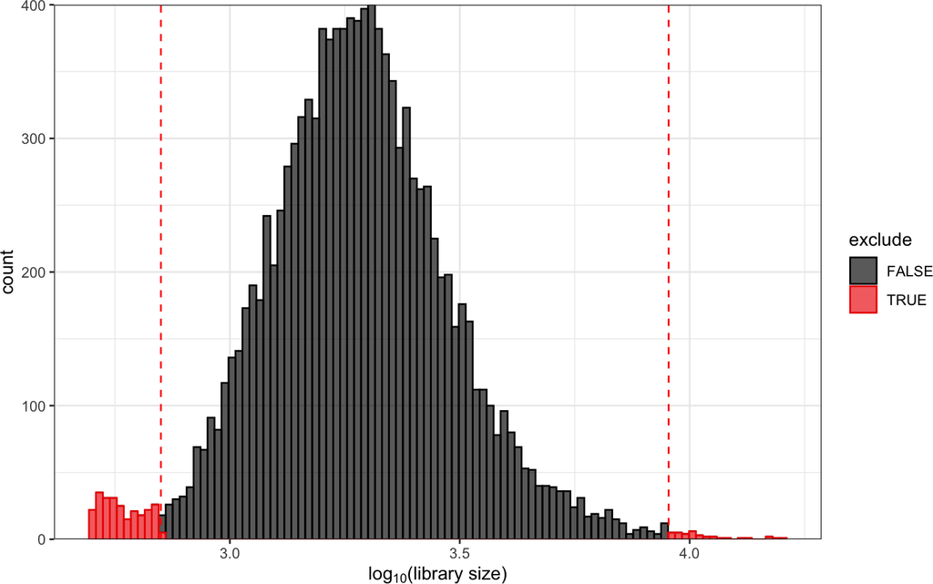

```r
x_titl <- expression("log"[10]*"(library size)")
lib_size_qc <- as.data.frame(colData(sce)) %>%
  mutate(exclude = ifelse(log10(total_counts) < 2.85 | log10(total_counts) > log10(9000), TRUE, FALSE)) %>%
  ggplot(aes(log10(total_counts), fill = exclude, color = exclude)) +
    geom_histogram(bins = 100, alpha = 0.65) +
    geom_vline(xintercept = 2.85, color = "red", linetype = "dashed") +
    geom_vline(xintercept = log10(9000), color = "red", linetype = "dashed") +
    scale_x_continuous(x_titl) +
    scale_y_continuous(expand = c(0,0)) +
    scale_color_manual(values = c("black", "red2")) +
    scale_fill_manual(values = c("black", "red2")) +
    theme_bw() +
    theme(plot.title = element_text(hjust = 0.5))

lib_size_qc
```

Based on the log distribution, we remove those cells with a library size lower than 10^2.85 = 707 UMI. Moreover, we also filter cells with > 9,000 UMI, which are likely doublets:

```r
table(sce$total_counts > 707 & sce$total_counts < 9000)
```

```
##
## FALSE  TRUE
##   286 11466
```

```r
keep_lib_size <- sce$total_counts > 707 & sce$total_counts < 9000
```

### 2.1.2 Cell coverage

We next filter by the cell coverage, which is the number of detected genes in each cell (i.e., number of genes with non-zero counts for a given cell). We want to ensure that the reads are distributed across the transcriptome. Thus, we rule out those cells that have an abnormally low number of detected genes.

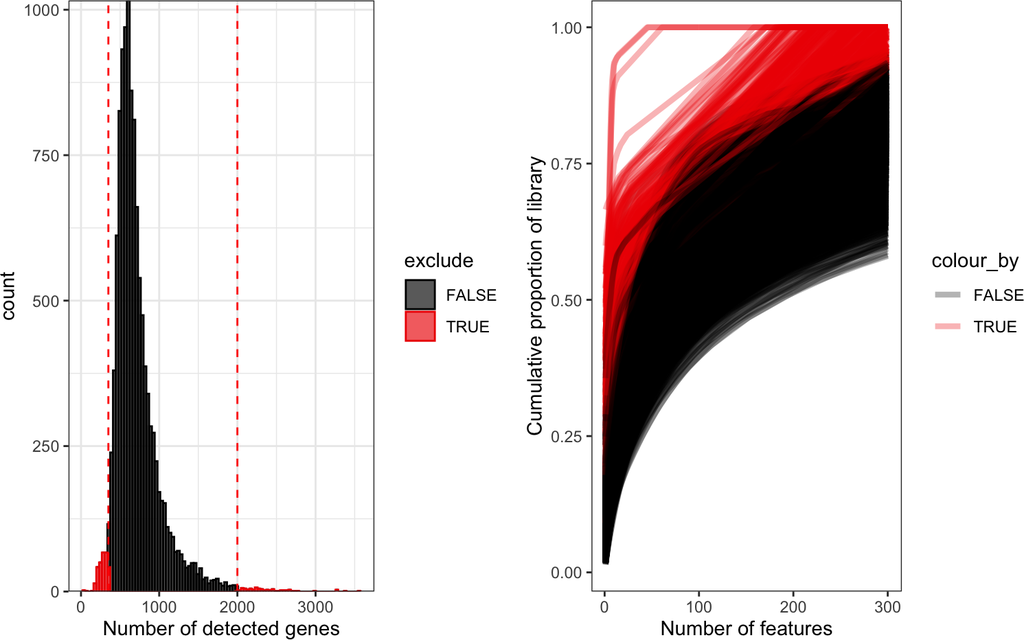

```r
cell_coverage_hist <- as.data.frame(colData(sce)) %>%
  mutate(exclude = ifelse(total_features_by_counts < 350 | total_features_by_counts > 2000, TRUE, FALSE)) %>%
  ggplot(aes(total_features_by_counts, fill = exclude, color = exclude)) +
    geom_histogram(bins = 100, alpha = 0.65) +
    geom_vline(xintercept = 350, color = "red", linetype = "dashed") +
    geom_vline(xintercept = 2000, color = "red", linetype = "dashed") +
    scale_x_continuous("Number of detected genes") +
    scale_y_continuous(expand = c(0,0)) +
    scale_color_manual(values = c("black", "red2")) +
    scale_fill_manual(values = c("black", "red2")) +
    theme_bw() +
    theme(plot.title = element_text(hjust = 0.5))

library_quality <- ifelse(sce$total_features_by_counts < 350, TRUE, FALSE)
sce$exclude <- library_quality
cumul_dis <- plotScater(
  sce,
  nfeatures = 300,
  colour_by = "exclude",
  exprs_values = "counts"
)
cumul_dis <- cumul_dis +
  scale_color_manual(values = c("black", "red2")) +
  theme_bw() +
  theme(panel.grid = element_blank())

cell_coverage_qc <- ggarrange(
  plotlist = list(cell_coverage_hist, cumul_dis),
  nrow = 1,
  ncol = 2
)
cell_coverage_qc
```

According to the distribution, we remove those cells with a cell coverage lower than 350 detected genes or higher than 2,000:

```r
table(sce$total_features_by_counts > 350 & sce$total_features_by_counts < 2000)
```

```
##
## FALSE  TRUE
##   361 11391
```

```r
keep_cell_cov <- sce$total_features_by_counts > 350 & sce$total_features_by_counts < 2000
```

### 2.1.3 Mitochondrial genes

The third cell filter we aim to apply is based on the percentage of counts of mitochondrial genes. It is expected that poor-quality cells are enriched for the expression of mitochondrial genes, likely because cells underwent apoptosis:

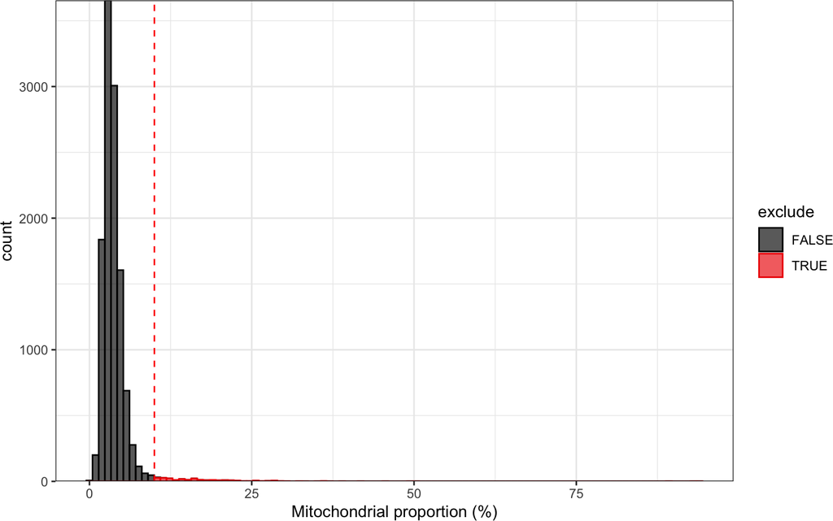

```r
mt_genes_qc <- as.data.frame(colData(sce)) %>%
  mutate(exclude = ifelse(pct_counts_MT > 10, TRUE, FALSE)) %>%
  ggplot(aes(pct_counts_MT, fill = exclude, color = exclude)) +
    geom_histogram(bins = 100, alpha = 0.65) +
    geom_vline(xintercept = 10, linetype = "dashed", color = "red") +
    scale_x_continuous("Mitochondrial proportion (%)") +
    scale_y_continuous(expand = c(0, 0)) +
    scale_color_manual(values = c("black", "red2")) +
    scale_fill_manual(values = c("black", "red2")) +
    theme_bw() +
    theme(plot.title = element_text(hjust = 0.5))

mt_genes_qc
```

According to the distribution, we remove those cells with a mitochondrial proportion greater than 10:

```r
table(sce$pct_counts_MT < 10)
```

```
##
## FALSE  TRUE
##   249 11503
```

```r
keep_mt <- sce$pct_counts_MT < 10
```

After establishing the threshold for the 3 QC metrics we can classify cells as high and low quality. Note that, although there are cells that are outliers in all 3 metrics, we only require a cell to be an outlier in a single metric to be considered as low-quality:

```r
sce$is_high_quality <- keep_lib_size & keep_cell_cov & keep_mt
sce$exclude <- !(sce$is_high_quality)
```

## 2.2 Joint QC

As a final validation, it is important to analyse the QC metrics jointly. Particularly, if high mitochondrial expression is associated with a large library size, these would represent metabolically active cells, which we should keep:

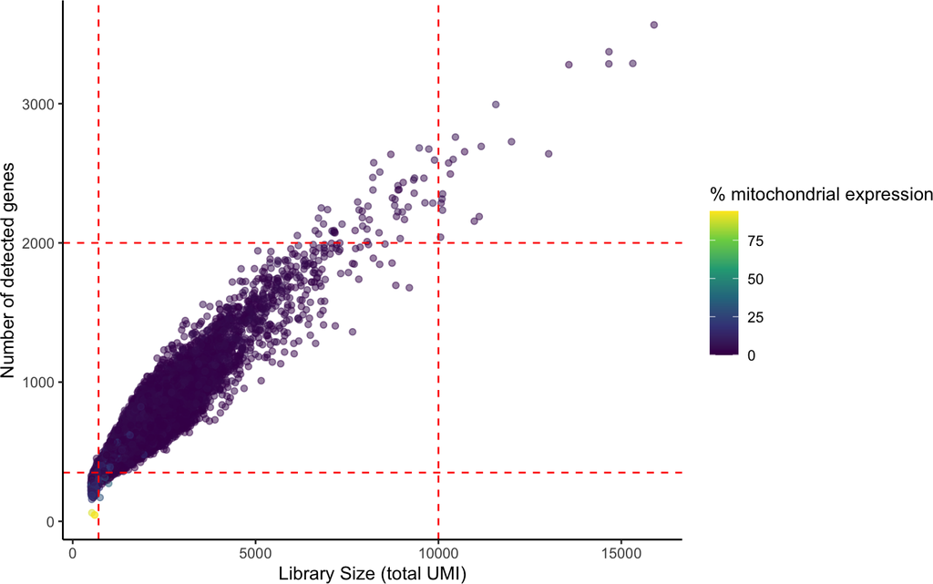

```r
# Number of detected genes VS library size
qc_titles <- c("Library Size (total UMI)", "Number of detected genes", "% mitochondrial expression")
joint_qc_gg <- colData(sce) %>%
  as.data.frame() %>%
  ggplot(aes(total_counts, total_features_by_counts, color = pct_counts_MT)) +
    geom_point(alpha = 0.5) +
    geom_vline(xintercept = 707, linetype = "dashed", color = "red") +
    geom_vline(xintercept = 10000, linetype = "dashed", color = "red") +
    geom_hline(yintercept = 350, linetype = "dashed", color = "red") +
    geom_hline(yintercept = 2000, linetype = "dashed", color = "red") +
    scale_color_viridis_c() +
    labs(x = qc_titles[1], y = qc_titles[2], color = qc_titles[3]) +
    theme_classic()
joint_qc_gg
```

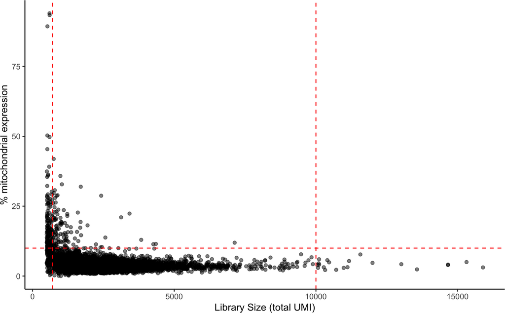

```r
saveRDS(joint_qc_gg, file = "results/R_objects/ggplots/scatter_plot_joint_qc_pbmc.rds")

# % mitochondrial expression VS library size
mt_vs_lib <- colData(sce) %>%
  as.data.frame() %>%
  ggplot(aes(total_counts, pct_counts_MT)) +
    geom_point(alpha = 0.5) +
    geom_vline(xintercept = 707, linetype = "dashed", color = "red") +
    geom_vline(xintercept = 10000, linetype = "dashed", color = "red") +
    geom_hline(yintercept = 10, linetype = "dashed", color = "red") +
    labs(x = qc_titles[1], y = qc_titles[3]) +
    theme_classic()

mt_vs_lib
```

As we can see, the cells with the highest percentage of mitochondrial genes also have the lowest UMI.

## 2.3 Cell filtering

```r
# Data frame qc summary metrics
qc_df <- as.data.frame(sce@colData)
col_sel <- c("donor", "condition", "total_counts",
             "total_features_by_counts", "pct_counts_MT")
qc_df <- qc_df[, col_sel]
qc_df$temperature <- case_when(
  qc_df$condition == "0h" ~ "0h",
  qc_df$condition %in% c("2h", "8h", "24h_RT", "48h_RT") ~ "21ºC",
  qc_df$condition %in% c("24h_4C", "48h_4C") ~ "4ºC"
)
qc_df$time <- str_remove(qc_df$condition, "(_RT|_4C)")
qc_df <- qc_df %>%
  mutate(time = factor(time, levels = c("0h", "2h", "8h", "24h", "48h")),
         temperature = factor(temperature, levels = c("0h", "21ºC", "4ºC")),
         donor = factor(donor, levels = c("male", "female"))) %>%
  group_by(time, temperature, donor) %>%
  summarise(num_cells_before_qc = n(),
            average_library_size = mean(total_counts),
            average_num_detected_genes = mean(total_features_by_counts),
            average_mitochondrial_fraction = mean(pct_counts_MT))
DT::datatable(qc_df)
```

|  | time | temperature | donor | num_cells_before_qc | average_library_size | average_num_detected_genes | average_mitochondrial_fraction |
| --- | --- | --- | --- | --- | --- | --- | --- |
| 1 | 0h | 0h | male | 4080 | 2109.61446078431 | 729.649019607843 | 3.8956644248965 |
| 2 | 0h | 0h | female | 1422 | 2239.69338959212 | 799.064697609001 | 3.84163690153453 |
| 3 | 2h | 21ºC | male | 271 | 2523.73800738007 | 813.380073800738 | 4.22353699107666 |
| 4 | 2h | 21ºC | female | 281 | 2478.48042704626 | 818.266903914591 | 4.63245074825764 |
| 5 | 8h | 21ºC | male | 2077 | 1835.28454501685 | 604.500722195474 | 3.82722927597678 |
| 6 | 8h | 21ºC | female | 352 | 2519.27556818182 | 795.036931818182 | 4.55559147934376 |
| 7 | 24h | 21ºC | male | 1379 | 1853.19941986947 | 615.889050036258 | 3.5939182535909 |
| 8 | 24h | 21ºC | female | 454 | 2420.83480176211 | 744.301762114537 | 3.82035379139853 |
| 9 | 24h | 4ºC | female | 454 | 2844.42070484582 | 1014.55726872247 | 4.21377101854213 |
| 10 | 48h | 21ºC | male | 478 | 2126.69037656904 | 622.050209205021 | 3.25756140698543 |

[output cut: 3 more lines]

```r
# Filter
table(sce$is_high_quality)
```

```
##
## FALSE  TRUE
##   487 11265
```

```r
sce <- sce[, sce$is_high_quality]
sce
```

```
## class: SingleCellExperiment
## dim: 20719 11265
## metadata(0):
## assays(1): counts
## rownames(20719): ENSG00000238009 ENSG00000237683 ... ENSG00000215700 ENSG00000215699
## rowData names(11): id name ... total_counts log10_total_counts
## colnames(11265): AAACCTGAGATCACGG-1.1 AAACCTGAGATCTGCT-1 ... TTTGTCAGTTGGTAAA-1 TTTGTCATCAAACAAG-1
## colData names(41): batch donor ... exclude is_high_quality
## reducedDimNames(0):
## spikeNames(1): MT
## altExpNames(0):
```

## 2.4 Doublet Detection

We will detect the doublets present in our dataset with DoubletFinder. DoubetFinder simulates doublets by averaging the UMI of two real cells. It subsequently project the simulations and real cells in PCA space and computes a nearest neighbors graph. Doublets are identified as those cells that have a proportion of artificial neighbors (pAN) greater than what you would expect by chance.

Note that different donors and temperatures were sequenced in different 10X lanes. Hence, as it is impossible to find doublets from two different sequencing libraries, we will split the object by library:

[output not shown]

[output cut: 225 more lines]

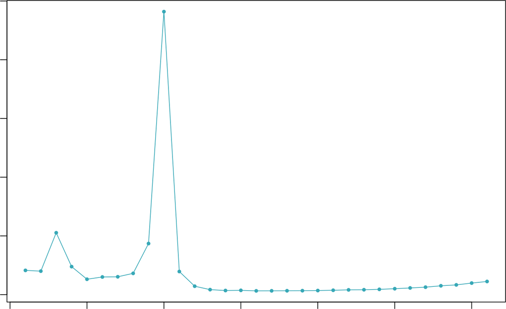

[output not shown]

[output cut: 220 more lines]

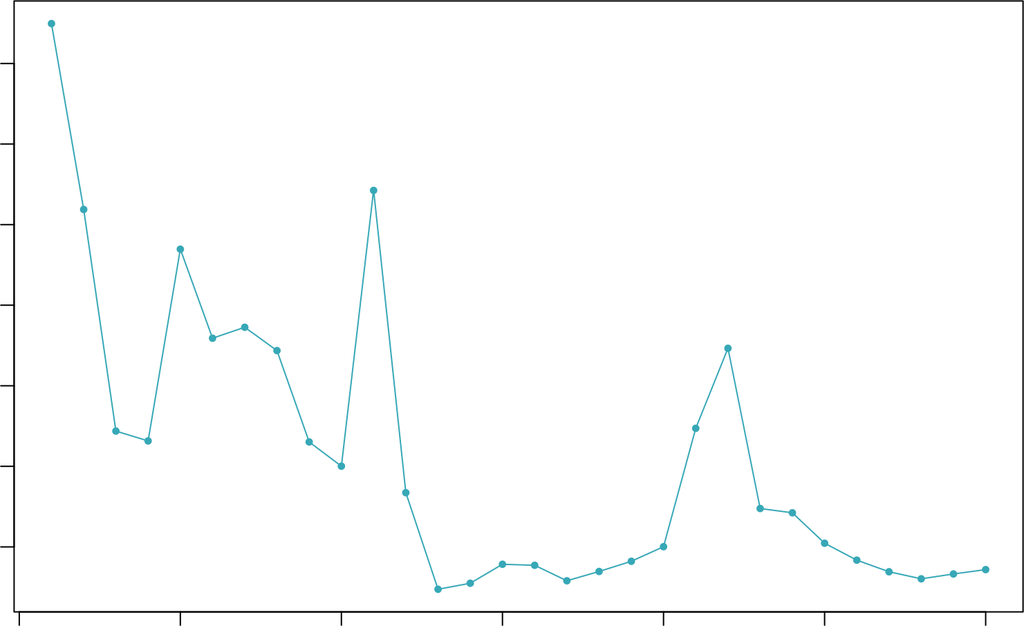

[output not shown]

[output cut: 220 more lines]

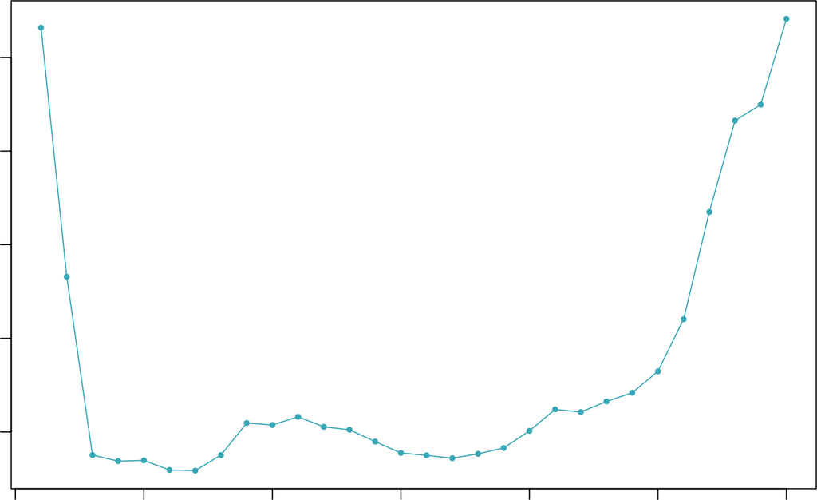

[output not shown]

[output cut: 220 more lines]

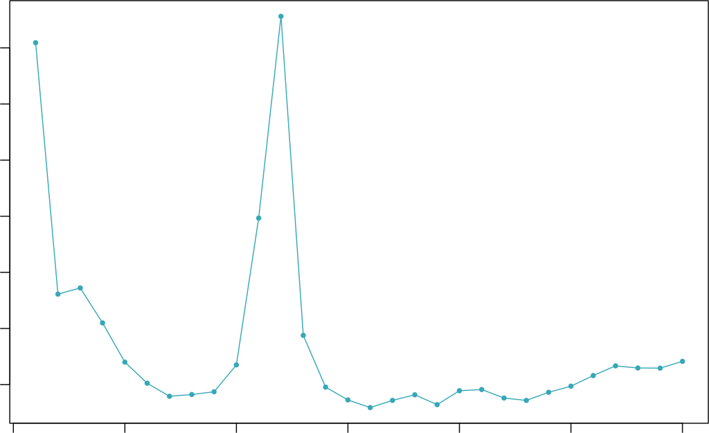

```r
# Convert to Seurat object
logcounts(sce) <- log(counts(sce) + 1) #otherwise I can't convert to Seurat
seurat <- as.Seurat(sce)

# Create list of seurat objects (split by library)
seurat$library <- str_c(seurat$donor, seurat$batch, sep = "_")
seurat_l <- SplitObject(seurat, split.by = "library")

# Preprocess independently
seurat_l <- purrr:::map(seurat_l, function(seurat) {
  seurat %>%
    NormalizeData() %>%
    FindVariableFeatures() %>%
    ScaleData() %>%
    RunPCA() %>%
    RunTSNE(dims = 1:15) %>%
    RunUMAP(dims = 1:15)
})

# pK identification
pk_dbl <- purrr::map_dbl(seurat_l, function(seurat) {
  sweep_res_list <- paramSweep_v3(seurat, PCs = 1:10, sct = FALSE)
  sweep_stats <- summarizeSweep(sweep_res_list, GT = FALSE)
  bcmvn <- find.pK(sweep_stats)
  pK <- as.numeric(as.character((bcmvn[which.max(bcmvn$BCmetric), "pK"])))
  pK
})
```

```r
# Run DoubletFinder
nExps <- c(0.07, 0.05, 0.07, 0.05)
seurat_l <- pmap(list(seurat_l, pk_dbl, nExps), function(seurat, pk, nExp_poi) {
  nExp_poi <- round(0.08 * ncol(seurat))
  seurat <- doubletFinder_v3(
    seu = seurat,
    PCs = 1:10,
    pN = 0.25,
    pK = pk,
    nExp = nExp_poi,
    reuse.pANN = FALSE,
    sct = FALSE
  )
})
```

[output not shown]

[output cut: 21 more lines]

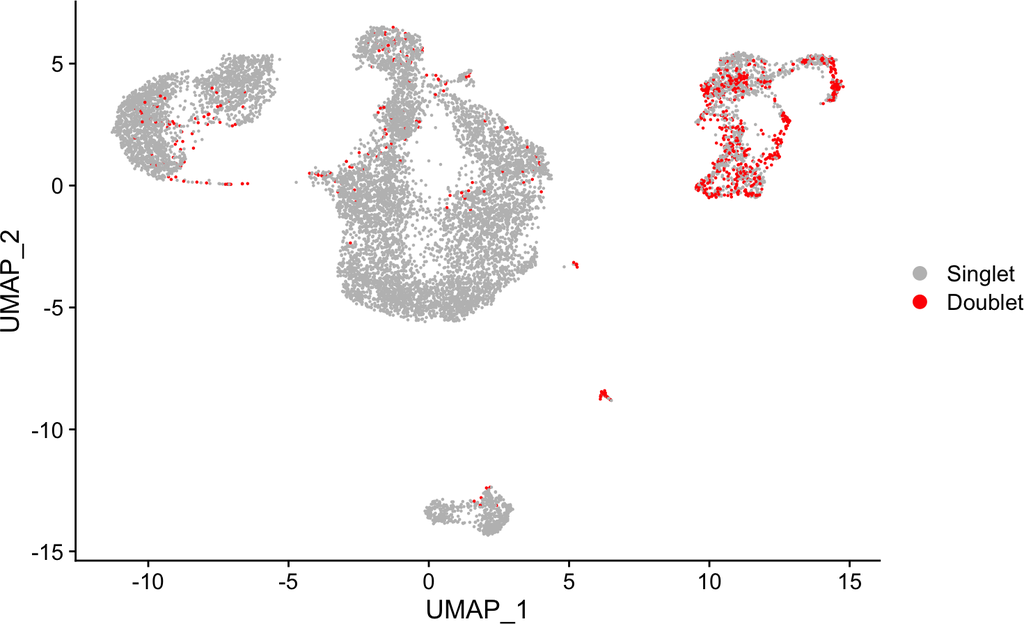

```r
# Visualize doublets
doublets_l <- purrr::map(seurat_l, function(seurat) {
  selection <- str_subset(colnames(seurat@meta.data), "^DF")
  df <- seurat@meta.data[, selection, drop = FALSE]
  colnames(df) <- "is_doublet"
  df
})
doublets_l <- purrr::map(doublets_l, rownames_to_column, var = "barcode")
doublets_df <- bind_rows(doublets_l, .id = "library")
rownames(doublets_df) <- doublets_df$barcode
doublets_df <- doublets_df[colnames(seurat), ]
seurat$is_doublet <- doublets_df$is_doublet
Idents(seurat) <- "is_doublet"
seurat <- NormalizeData(seurat)
seurat <- pre_process_seurat(seurat)
doublets_umap <- DimPlot(seurat, reduction = "umap", cols = c("gray", "red"))
doublets_umap
```

```r
saveRDS(doublets_umap, file = "results/R_objects/ggplots/umap_doublets_pbmc.rds")

# Remove doublets
symbols <- rowData(sce)$name
seurat <- subset(seurat, idents = "Singlet")
sce <- as.SingleCellExperiment(seurat)
rownames(sce) <- symbols

# Redo QC summary for high-quality cells
qc_df2 <- as.data.frame(sce@colData)
col_sel <- c("donor", "condition", "total_counts",
             "total_features_by_counts", "pct_counts_MT")
qc_df2 <- qc_df2[, col_sel]
qc_df2$temperature <- case_when(
  qc_df2$condition == "0h" ~ "0h",
  qc_df2$condition %in% c("2h", "8h", "24h_RT", "48h_RT") ~ "21ºC",
  qc_df2$condition %in% c("24h_4C", "48h_4C") ~ "4ºC"
)
qc_df2$time <- str_remove(qc_df2$condition, "(_RT|_4C)")
qc_df2 <- qc_df2 %>%
  mutate(time = factor(time, levels = c("0h", "2h", "8h", "24h", "48h")),
         temperature = factor(temperature, levels = c("0h", "21ºC", "4ºC")),
         donor = factor(donor, levels = c("male", "female"))) %>%
  group_by(time, temperature, donor) %>%
  summarise(num_cells_after = n(),
            average_library_size = mean(total_counts),
            average_num_detected_genes = mean(total_features_by_counts),
            average_mitochondrial_fraction = mean(pct_counts_MT))
qc_df$num_cells_after_qc <- qc_df2$num_cells_after
col_sel <- c("time", "temperature", "donor", "num_cells_before_qc",
             "num_cells_after_qc", "average_library_size", "average_num_detected_genes",
             "average_mitochondrial_fraction")
qc_df <- qc_df[, col_sel]
DT::datatable(qc_df)
```

|  | time | temperature | donor | num_cells_before_qc | num_cells_after_qc | average_library_size | average_num_detected_genes | average_mitochondrial_fraction |
| --- | --- | --- | --- | --- | --- | --- | --- | --- |
| 1 | 0h | 0h | male | 4080 | 3667 | 2109.61446078431 | 729.649019607843 | 3.8956644248965 |
| 2 | 0h | 0h | female | 1422 | 1273 | 2239.69338959212 | 799.064697609001 | 3.84163690153453 |
| 3 | 2h | 21ºC | male | 271 | 240 | 2523.73800738007 | 813.380073800738 | 4.22353699107666 |
| 4 | 2h | 21ºC | female | 281 | 245 | 2478.48042704626 | 818.266903914591 | 4.63245074825764 |
| 5 | 8h | 21ºC | male | 2077 | 1874 | 1835.28454501685 | 604.500722195474 | 3.82722927597678 |
| 6 | 8h | 21ºC | female | 352 | 286 | 2519.27556818182 | 795.036931818182 | 4.55559147934376 |
| 7 | 24h | 21ºC | male | 1379 | 1177 | 1853.19941986947 | 615.889050036258 | 3.5939182535909 |
| 8 | 24h | 21ºC | female | 454 | 398 | 2420.83480176211 | 744.301762114537 | 3.82035379139853 |
| 9 | 24h | 4ºC | female | 454 | 378 | 2844.42070484582 | 1014.55726872247 | 4.21377101854213 |
| 10 | 48h | 21ºC | male | 478 | 427 | 2126.69037656904 | 622.050209205021 | 3.25756140698543 |

[output cut: 3 more lines]

```r
saveRDS(qc_df, file = "results/R_objects/qc_summary_table_pbmc.rds")
```

# 3 Gene QC

## 3.1 Gene filtering

Gene filtering must be performed right after cell filtering, as some genes may be exclusively expressed in poor-quality cells. The purpose of this step is to remove lowly expressed genes that do not possess enough information for reliable statistical analysis. Furthermore, the discreteness of the counts can affect the reliability of downstream analysis. These genes contain a great deal of dropout events: transcripts that are not detected in the final dataset even though the gene is expressed in the cell.

We will filter genes with a mean expression below a certain cutoff. Again, such cutoff will be data-driven, so let us start by visualizing the distribution of the mean expression:

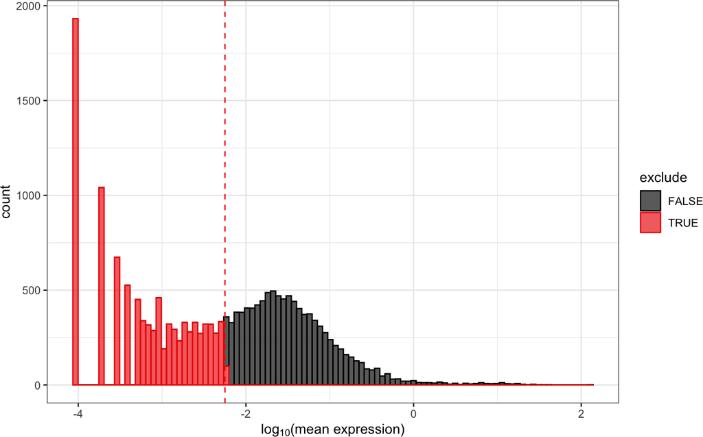

```r
mean_expr_df <- data.frame(
  gene = rownames(sce),
  mean_expression = rowMeans(counts(sce))
)
x_titl <- expression("log"[10]*"(mean expression)")
mean_expr_gg <- mean_expr_df %>%
  mutate(exclude = ifelse(log10(mean_expression) < -2.25, TRUE, FALSE)) %>%
  ggplot(aes(log10(mean_expression), fill = exclude, color = exclude)) +
    geom_histogram(bins = 100, alpha = 0.65) +
    geom_vline(xintercept = -2.25, color = "red", linetype = "dashed") +
    scale_x_continuous(x_titl) +
    scale_fill_manual(values = c("black", "red2")) +
    scale_color_manual(values = c("black", "red2")) +
    theme_bw() +
    theme(plot.title = element_text(hjust = 0.5))

write.table(
  mean_expr_df,
  file = str_c("results/tables/", date, "_mean_gene_expression.tsv"),
  sep = "\t",
  row.names = FALSE,
  col.names = TRUE
)
ggsave(
  filename = str_c("results/plots/", date, "_mean_gene_expression.pdf"),
  plot = mean_expr_gg,
  device = "pdf",
  height = 7,
  width = 8
)
mean_expr_gg
```

```r
saveRDS(mean_expr_gg, "results/R_objects/ggplots/histogram_gene_qc_pbmc.rds")
```

We see that the distribution is bimodal, with the first peak corresponding to lowly expessed genes. We want our cutoff to fall somewhere between the two peaks, so a mean expression of 10<sup>-2.25</sup> = 0.0056 UMI is a good choice:

```r
keep_genes <- log10(mean_expr_df$mean_expression) > -2.25
table(keep_genes)
```

```
## keep_genes
## FALSE  TRUE
## 10931  9788
```

```r
sce <- sce[keep_genes, ]
sce
```

```
## class: SingleCellExperiment
## dim: 9788 10364
## metadata(0):
## assays(2): counts logcounts
## rownames(9788): AP006222.2 FAM41C ... PNRC2 SRSF10
## rowData names(5): vst.mean vst.variance vst.variance.expected vst.variance.standardized vst.variable
## colnames(10364): AAACCTGAGATCACGG-1.1 AAACCTGAGATCTGCT-1 ... TTTGTCAGTTGGTAAA-1 TTTGTCATCAAACAAG-1
## colData names(46): batch donor ... nFeature_RNA ident
## reducedDimNames(3): PCA TSNE UMAP
## spikeNames(0):
## altExpNames(0):
```

## 3.2 Identify highest expressed genes

In addition, we want to assess which are the highest expressed genes. We expect it to be housekeeping genes, such as actin beta (ACTB).

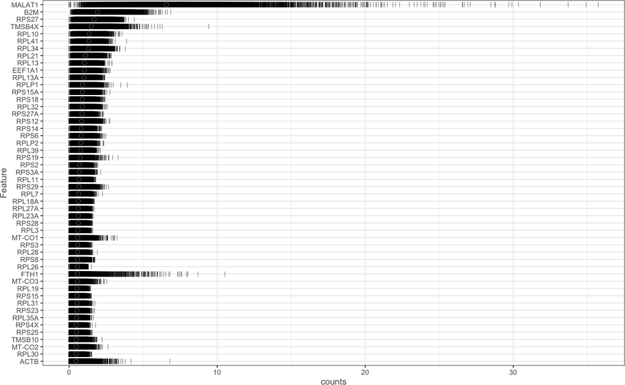

```r
rowData(sce)$symbol <- rownames(rowData(sce))
highest_expr_genes <- plotHighestExprs(sce, feature_names_to_plot = "symbol")
highest_expr_genes
```

# 4 Normalization

We want to correct for two biases:

1. Library size: if cell A has twice the library size of cell B, we expect that, on average, every gene in cell A will have twice the number of counts of cell B.
2. RNA composition: we assume that most genes in cell A are not over-expressed in cell B. However, due to dropout events this might not be the case, so that the genes expressed in cells with low RNA composition (low cell coverage) will tend to be biased towards overexpression.

We will use the [`scran`](https://genomebiology.biomedcentral.com/articles/10.1186/s13059-016-0947-7) package to compute size factors for the count matrix and correct for the former biases:

```r
sce <- computeSumFactors(sce)
summary(sizeFactors(sce))
```

```
##    Min. 1st Qu.  Median    Mean 3rd Qu.    Max.
##  0.2638  0.6880  0.8633  1.0000  1.1840  4.4787
```

```r
sce <- normalize(sce)
```

We can see that the previous command introduced a new matrix in the “assays” layer of the SingleCellExperiment object, corresponding to the log-normalized expression matrix:

```r
assays(sce)
```

```
## List of length 2
## names(2): counts logcounts
```

```r
logcounts(sce)[1:6, 1:6]
```

```
## 6 x 6 sparse Matrix of class "dgCMatrix"
##            AAACCTGAGATCACGG-1.1 AAACCTGAGATCTGCT-1 AAACCTGAGGCTAGAC-1 AAACCTGAGGGATCTG-1 AAACCTGAGTCCATAC-1 AAACCTGAGTCGTTTG-1
## AP006222.2            0.6487146           .                  .                  .                         .                  .
## FAM41C                .                   .                  .                  .                         .                  .
## NOC2L                 .                   .                  .                  1.098562                  .                  .
## HES4                  .                   .                  .                  .                         .                  .
## ISG15                 .                   0.963624           0.902371           1.098562                  .                  .
## TNFRSF18              .                   .                  .                  .                         .                  .
```

Interestingly, we see that the size factors correlate with the library size, whilst the condition partially explains the scatter along the diagonal, like representing differential RNA composition as described in [here](https://osca.bioconductor.org/normalization.html):

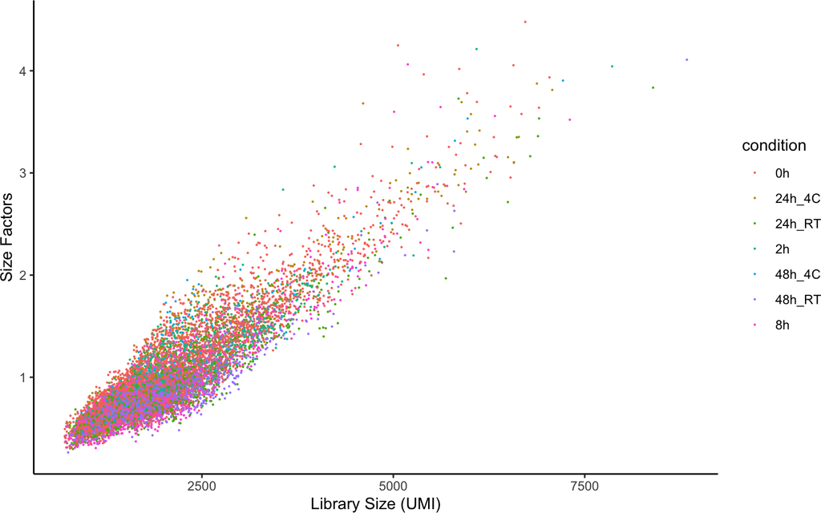

```r
scran_df <- data.frame(
  total_counts = sce$total_counts,
  size_factors = sizeFactors(sce),
  condition = sce$condition
)
ggplot(scran_df, aes(total_counts, size_factors, color = condition)) +
  geom_point(size = 0.1) +
  labs(x = "Library Size (UMI)", y = "Size Factors") +
  theme_classic()
```

```r
summary(lm(sizeFactors(sce) ~ sce$total_counts))
```

```
##
## Call:
## lm(formula = sizeFactors(sce) ~ sce$total_counts)
##
## Residuals:
##      Min       1Q   Median       3Q      Max
## -0.79812 -0.13472 -0.00732  0.11340  1.78618
##
## Coefficients:
##                   Estimate Std. Error t value Pr(>|t|)
## (Intercept)      3.847e-03  5.137e-03   0.749    0.454
## sce$total_counts 4.858e-04  2.302e-06 211.015   <2e-16 ***
## ---
## Signif. codes:  0 '***' 0.001 '**' 0.01 '*' 0.05 '.' 0.1 ' ' 1
##
## Residual standard error: 0.2061 on 10362 degrees of freedom
## Multiple R-squared:  0.8112, Adjusted R-squared:  0.8112
## F-statistic: 4.453e+04 on 1 and 10362 DF,  p-value: < 2.2e-16
```

**Important note:** in our experience, different versions of `scran` yield slightly different logcounts. As the logcounts slot is the input to virtually every analysis downstream, the values might not reproduce exactly, although the results and conclusions should remain unchanged.

# 5 Save filtered and normalized SingleCellExperiment object

We have our SCE filtered and normalized. We can now select the columns of interest in the colData and rowData slots, and then save the object as .RDS file to use in future analysis.

```r
# colData(sce) <- colData(sce)[, c("batch", "donor", "condition")]
# saveRDS(
#   sce,
#   file = "results/R_objects/10X_SingleCellExperiment_filt&norm.RDS"
# )
```